# Knowledge is built, not received

Week 7 · Chapter 8 · Cognitive Learning Theory and Principles of Learning

Study · Week 7

Read Chapter 8 of the textbook (Eggen & Kauchak, 2025) before you read this brief. Last week you studied how little the brain can hold. This week you study what the brain does with the information it receives, and why a learner can hold every fact correctly and still understand nothing.

About 25 minutes plus the OECD video: reading, one place you stop and write, and 8 quick checks.

Pair this with **the Walkthrough**.

## Why this chapter matters now: PISA 2025

- **Scores are falling.** Across the OECD, 15-year-olds’ reading and math are at their lowest on record, and the steepest fall is in evaluating information and reasoning from sources.

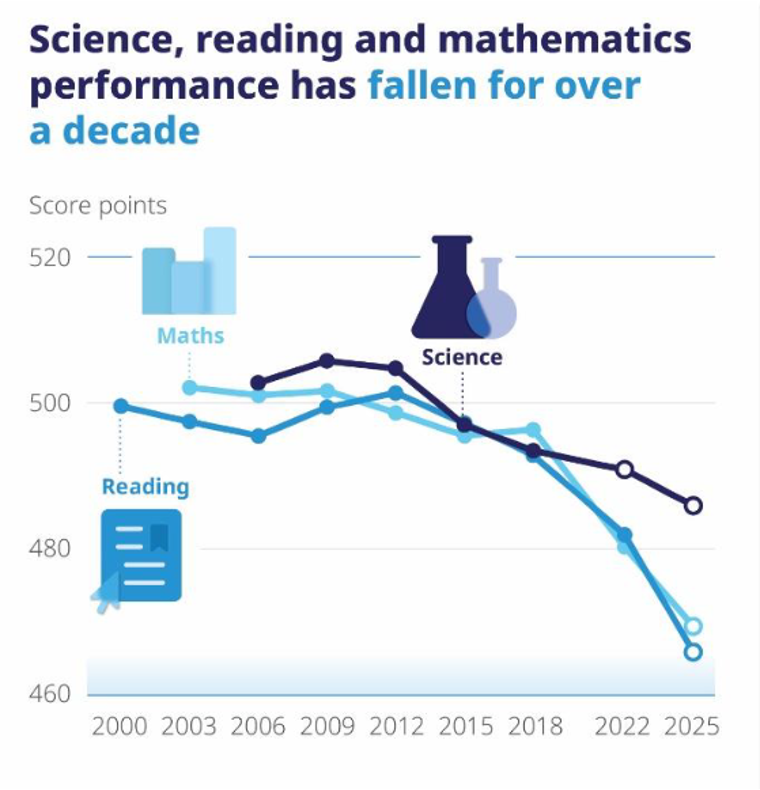

OECD average PISA scores, 2000–2025. Source: OECD, PISA 2025 Results.

- **AI use is rising, and how students use it matters.** About half of OECD 15-year-olds use AI every week to learn. Those who use it daily to summarize or draft score lower than those who never do. Singapore has one of the highest AI-use rates and still ranks second in the world.
- **Watch** the OECD’s short video below with one question in mind: if a chatbot can deliver the content, what is school for? *In person:* bring your answer to Tuesday’s class. *Online:* think it through as you work this week.

[video not shown]

If the video does not load: [watch it on YouTube](https://www.youtube.com/watch?v=MiHzd0aTIkA).

## A belief novice teachers may have

**If an explanation is clear enough, the student will understand.** Every teacher believes this a little, and for that reason we work hard on our explanations. If it were true, the best-explained subjects would have no misconceptions, and Priya (who wrote down every clear explanation she was given) would have scored 8 of 8.

The whole chapter argues for the last principle in the list below, and that principle changes what a lesson is for.

## Eight principles of constructivism

Chapter 8 presents constructivism as principles you can use for design. Each one has a cost, so ask *what is the disadvantage?* of every line. A principle without a cost is a slogan.

Learners actively construct knowledge Learners build knowledge out of whatever they already know. *Cost:* what they build may not be what you taught.

Prior knowledge shapes new learning Learners interpret new information with their schemas, so the same explanation can become a different lesson for each learner. *Cost:* you have to know what learners already think, and you usually do not.

Learners seek coherence and meaning When a new fact does not fit, learners make it fit (assimilation, from Week 3) or set it aside. *Cost:* a coherent wrong model is more stable than an incoherent right one.

Practice is essential for long-term learning Practice includes retrieval, spacing and generation from Week 6. *Cost:* practice of the wrong thing entrenches it.

Deep understanding requires meaningful learning In Ausubel’s (1968) terms, *meaningful* learning is attached to a structure, whereas *rote* learning is attached to nothing. Both can produce a correct answer on Friday, but only meaningful learning survives to March.

Connecting to the real world enhances learning Connections create more retrieval routes and more transfer. *Cost:* the real-world context can hide the structure, which is the problem in the Week 8 case.

Interaction supports learning and conceptual change This is Vygotsky’s (1978) argument with a mechanism: when learners have to explain, defend or argue, they show a schema that others can examine. *Cost:* time, noise, and a teacher who talks less.

Explanation alone is insufficient **The one that matters most.** A clear explanation is an input to construction, and it cannot replace construction. Learning depends on what the learner *does* after the explanation.

Compare the last principle with your own experience of being taught. The lessons you remember are almost never the clearest explanations. They are the times you had to **do something with it**: argue, build, predict, or be wrong in public.

True or false?

A coherent wrong idea is easier to replace than a confused one.

Not quite The opposite is true. A coherent wrong model **works** in the learner’s experience, so it resists replacement, whereas nothing holds a confused one together.

Right Coherence makes a wrong model stable. That is why misconceptions survive good explanations.

## Meaningful and rote learning

Priya’s case depends on a distinction that Ausubel made.

Rote learning: stored verbatim, attached to nothing. The learner can retrieve it when the cue matches the storage (*define osmosis* → the definition), but not when the cue is a celery stick. A definition on its own is rote learning.

Meaningful learning: attached to an existing structure (schema). The learner can retrieve it from many directions, because it is connected to many things, and can run it forward: *salt outside → water leaves → cell shrinks → limp.*

Inert knowledge: correct, stored, and unused. Whitehead used this term for knowledge that the learner has and cannot use when it is needed. **Priya’s notes are inert**, and so is most of what most people remember from school.

Advance organizer: Ausubel’s solution. A structure given *before* the content, at a higher level of generality, so that the new material can attach to it. It works as a scaffold for a schema, and it is different from a summary. For example, students hear *“Water moves toward salt”* before the word *osmosis*.

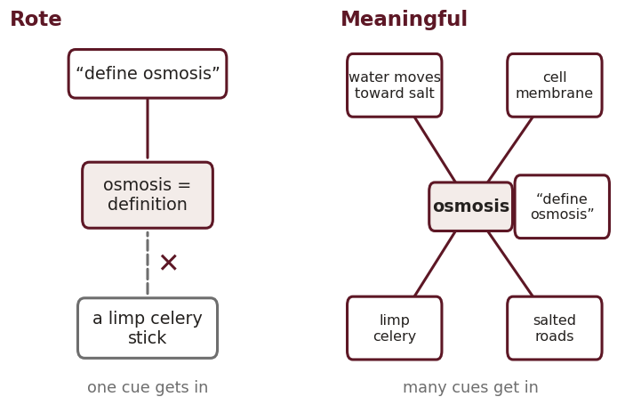

Rote learning has one way in. Meaningful learning is connected, so many cues reach it.

True or false?

A student who scores well on a definitions quiz has learned the concept meaningfully.

Not quite In a definitions quiz, the cue matches the storage, so rote learning can pass it. Meaningful learning shows when the cue is new, such as a celery stick or a salted road.

Right Definitions can be rote. Ask for a novel case to tell the difference.

**Every assessment Priya has met rewarded rote learning and called it understanding.** When assessments ask students to *define*, *list* and *label*, students learn what the system measures, and Priya learned it correctly. We should expect her to ask, *“Is there another word I was supposed to use?”* The last test asked for an explanation, and nobody had taught her how to write one.

## Misconceptions and conceptual change

A misconception is more than a missing fact. It is a **coherent, working schema that happens to be wrong**, and because it works in the learner’s experience, it resists replacement with the correct knowledge.

Consider these examples:

*democracy means majority rule* · *evolution means survival of the strongest* · *food with chemical names is dangerous* · and one for future teachers: *a teacher who believes **repetition** is the most effective method, and ignores the evidence that elaboration and interaction matter.*

Confirmation bias Learners select evidence that fits the schema. A student who thinks climate change is a hoax finds the articles that agree and rejects the science teacher. This is assimilation with a search engine.

Misinformation effect Exposure to a wrong claim alters the stored knowledge, even when the source is later discredited. People tend to retain what they heard first.

Conceptual change: the four conditions. According to Posner et al. (1982), the learner must be **dissatisfied** with the old idea, and the new one must be **intelligible**, **plausible**, and **fruitful**. A clear explanation supplies only the second condition.

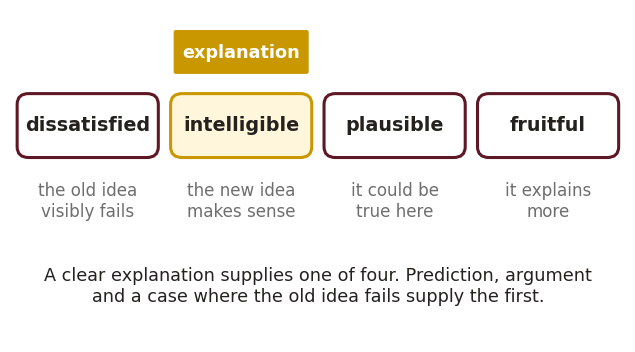

The four conditions for conceptual change (Posner et al., 1982). A clear explanation supplies only one.

An explanation can make an idea *intelligible*, but it cannot make the learner *dissatisfied*. Only an experience in which the old idea visibly fails can do that. **For this reason, interaction, prediction and argument are the mechanism of conceptual change, and teachers should not treat them as enrichment.**

Commit first

Two students use the same chatbot to revise osmosis for the same twenty minutes. Both get correct explanations. Ethan reads his, copies and stops. Fabian asks *“why does salt pull water out and not push it in — that seems backwards,”* argues with the answer twice, then asks for a case where his intuition would be right.

**Name the move Fabian made that Ethan did not, and say which of the four conditions for conceptual change it produced.** Describe an action and avoid personality traits. Two or three sentences.

**He stated his own schema and made the tool argue with it.**

*“That seems backwards”* is a prediction, because it states his prior model. The tool’s answer now conflicts with something, and the conflict produces **dissatisfaction**, the condition that explanation alone cannot supply. When he asks for a case where his intuition would be right, he elaborates in the other direction. He finds the boundary of the new idea, which makes it **plausible** and understandable at his current development.

Ethan received an intelligible explanation, but he had exposed no idea of his own that it could attach to. Both students used the same tool for the same minutes, and the difference is what each learner did.

Your own tool has the same design question in Milestone 2 Part 4: what does it do when it meets the learner’s wrong idea, and how does it *elicit it first*?

Check yourself

Students believe democracy simply means majority rule. Which move is most likely to make them **dissatisfied** with that idea?

That supplies intelligible A clear definition is the condition explanation already supplies.

Yes The prediction puts their model on the table, and the case makes it fail in front of them. That is dissatisfaction.

Tests the definition A definitions quiz rewards rote learning and does not change the old model.

Another explanation A well-made summary is another explanation, so it supplies the same condition, intelligible.

## Using the principles in design

Active processing Any task that makes the learner generate, transform or apply an idea, which listening to a lecture does not require. It puts *explanation alone is insufficient* into practice.

Worked examples: why they are not cheating. For a novice, studying a fully worked solution is better than solving from scratch, because it builds the schema without overloading working memory (Week 6). **Then the guidance fades**: the learner completes the last step, then the last two, then solves the problem. A worked example (Scaffolding, Vygotsky) that never fades undermines independence.

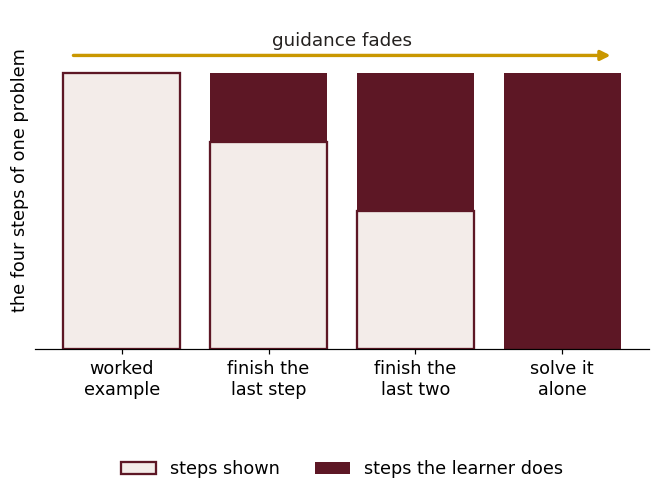

A worked example, faded. The steps shown shrink as the steps the learner does grow.

Expertise reversal The same worked example that helps a novice *hurts* a learner who already has the schema, because it becomes extraneous load. One design for the whole room is therefore wrong for half of it.

True or false?

Worked examples help every learner, so a teacher should keep using them with the whole class all unit.

Not quite **Expertise reversal:** once a learner has the schema, the worked example becomes extraneous load. Guidance has to fade, and the pace differs across learners.

Right They help novices and hurt learners who already have the schema. Fade them.

Feedback: timing and specificity. *Correct/incorrect* is nearly useless, whereas *pointing out where the reasoning fails* is necessary. Immediate feedback helps procedural learning, and slightly delayed feedback can help retention. Feedback that tells learners what to do next helps revision and future tasks.

Check yourself

Which feedback on a lab write-up is most likely to improve the next one?

Nearly useless Correct/incorrect says nothing about where the reasoning failed.

No information Praise with no content gives the learner nothing to revise.

Yes It points to where the reasoning breaks and says what to do next.

A number with no direction A grade ranks the work. It does not show how to fix it.

### On using examples

An example (an exemplar, a worked case or a model answer) is helpful when it:

| **SHOWS** | the final product — what done looks like |
| --- | --- |
| **EXPLAINS** | the hidden process — the steps the expert has automatized |
| **PREDICTS** | expected behaviors and likely contradictions or errors |
| **CONNECTS** | to the students’ world — a retrieval route they already own |
| **ALIGNS** | with how it will be graded — the structure the assessment will actually ask for |

**PREDICTS is the line that does the conceptual-change work**. An example that exposes the misconception before the learner makes it turns the learner’s *“that seems backwards”* into part of the lesson. Priya’s teacher had a definition on the board, but it did not help students question whether the principle of osmosis made sense to them.

The video below shows what the example was about.

[video not shown]

## Explanations from AI

A language model has been trained on a very large number of explanations of your topic. When you ask it to teach, it produces the **probable explanation**, which is the one most often written in its training data. Very often, your learners have already received that explanation and did not learn from it. **AI does not know their misconception unless it is told, and it does not ask.**

Your Friction Move this week (**Verify**) checks this question: did the explanation build from what a learner already knows, or did it state facts in a good order? The tool can do the first, as it did for Fabian, but only when it receives the learner’s schema. A tool designed to teach has to be told to ask for the wrong idea first. You write that instruction as a rule in Milestone 2, Part 4.

True or false?

If you ask a chatbot to explain osmosis, it will first find out what you already believe about it.

Not quite It produces the **probable** explanation and does not ask. Unless you put your idea in front of it, it never meets your misconception.

Right It explains first and does not ask. Fabian got a better answer by stating his idea.

## Check yourself

Check yourself

A student can define every term in a unit correctly and cannot explain a novel case that uses them. The most precise description of the student challenge is:

Wrong week Nothing here is about capacity. The student retrieved every definition perfectly and is missing the structure that connects them.

Close, but there is no conception to correct A misconception is a coherent wrong model, and this student has correct pieces and no model. The situation is worse in one way, because there is nothing to be dissatisfied with, and easier in another.

Yes The definitions are stored verbatim, can be retrieved with the matching cue, and cannot be used when the cue is a celery stick. Ausubel calls this rote, and Whitehead (1929) calls it inert. Multiple choice and memory tests reward it.

The diagnosis that requires nothing of the teacher She takes color-coded notes and came to ask about the grade, so a lack of effort does not explain the result.

Check yourself

A teacher discovers that a third of the class believes heavier objects fall faster. She explains, clearly and with a diagram, that they do not. Two weeks later a third of the class believes heavier objects fall faster. By Chapter 8, the most likely reason is:

The intuitive answer, and the chapter’s target A clearer explanation is a better version of what already failed. Explanation helps with *clarity*, but it can fail to produce *accommodation*.

Yes The old model still works in their experience, because a feather does fall slower. Until they predict, watch the prediction fail, and have to account for it, the new idea remains a fact they were told beside a model they use. Conceptual change needs the challenge.

Not established, and not sufficient Students who attend perfectly to an explanation still get only intelligibility. This answer uses a Week 6 explanation for a different problem.

Wrong mechanism Interference is competition between stored material. Here the original schema survives intact because nothing displaced it.

By now you should **Have an answer to case question 1**, which explains in the chapter’s words what Priya has and what she does not.

**One misconception in your own subject** that survives being explained.

**Your Fabian move**, the last time you argued with a tool instead of only reading its answer. If you cannot think of one, that is also a finding.

*This week feeds Milestone 2, Parts 2 and 4: what must be held and what must be connected, and what your tool does when it meets the wrong idea.*

## Sources

Ausubel, D. P. (1968). *Educational psychology: A cognitive view.* Holt, Rinehart and Winston.

Eggen, P. D., & Kauchak, D. P. (2025). *Using educational psychology in teaching* (12th ed.). Pearson. **This week: Chapter 8.**

OECD. (2026). *PISA 2025 results (Volume I).* OECD Publishing.

Posner, G. J., Strike, K. A., Hewson, P. W., & Gertzog, W. A. (1982). Accommodation of a scientific conception: Toward a theory of conceptual change. *Science Education, 66*(2), 211–227.

Schraw, G., & Dennison, R. S. (1994). Assessing metacognitive awareness. *Contemporary Educational Psychology, 19*(4), 460–475.

Vygotsky, L. S. (1978). *Mind in society: The development of higher psychological processes.* Harvard University Press.

Whitehead, A. N. (1929). *The aims of education and other essays.* Macmillan.